# Data Visualization with ggplot2 (Part 3)

Statistical Plots (Chapter 1)

Seun Odeyemi

2019-04-10

## Load Libraries

```r
library(readr)
library(dplyr)
library(ggplot2)
# library(ggplot2movies)
library(tidyr)
library(skimr)
library(knitr)
library(kableExtra)
library(RColorBrewer)
library(grid)
library(ggthemes)
library(forcats)
library(GGally)
library(here)
```

## Introduction

Welcome to data visualization with ggplot2 (part 3). This course assumes you are familiar with the concepts and functions of data visualization introduced in the first two courses, part 1 & 2. Those courses should have give you a pretty good idea about what good data visualization is and how to achieve it. Since, this is an advanced course we are to dig a bit deeper into some more advanced ggplot2 functions. Before we get to that we will cap off the material we began in the first two courses by rounding out your knowledge with some niche topics. We will begin by exploring two kinds of specialized plots. In **Chapter 1**, we will consider the first type of specialized plots, those suited for a data savvy audience. These are statistical plots you wouldn’t normally see in the popular press like *boxplots* and *density plots*. Plus, we will consider how to combine several variables. In **Chapter 2**, we will move on to the second type of specialized plots, those that are suited for a specific data type. We will begin by putting some fundamental concepts of working with large datasets into perspective. And then we will see some specific cases like **kenuri plots** (?), *networks*, and *diagnostic plots*.

This topic will continue into **Chapter 3** where we’ll consider two main classes of maps: *coral plots* and *carthographic maps*. Finally, we’ll see many concepts come together with the last type of specialized plot, **animations**—it’s likely we’ll cover `gganimate` in this section—which adds video frames as another mapping aesthetic. Depending on your area of expertise you may find out you seldom have a need to use this specialized plot types, but it is still useful to know what’s possible within the ggplot2 framework. In **Chapter 4** we are going to get under the hood by digging into the internals of ggplot2 objects. For this we’ll begin by looking at the basics of the `grid` package on which ggplot2 is built. The next step is to begin manipulating graphical objects that we made with ggplot2 and look at more efficient ways of doing that with some built-in functions in ggplot2 such as `ggplot_build()`. In the last part, we’ll make use of a useful accessory package called `gridExtra`. In **Chapter 5**, we will bring our series on ggplot2 to a close with two case studies. In the first case study we’ll look at a feature that was introduced in ggplot2 (2.0), *extensions*. We will understand how to build a new geom or stat_function from scratch. This will allow us to use ggplot2 to create exactly the statistics and visualizations we want in a more straightforward manner. In the second case study we are going to reproduce a classic plot by **Edward Tufte** using data familiar to everyone, the weather. Using ggplot2, we will create a unique plot drawing on what we’ve learned over all three courses. To cap all off, we are going to combine our Tufte weather plot with ggplot2 extensions and turn our unique plot type into a flexible, efficient, and reproducible plot type that we can use with any dataset of the appropriate type.

## Refresher (1)

As a refresher to statistical plots, let’s build a scatter plot with an additional statistic layer.

```r
# Using the sample function to do a random sampling of a dataset
# library(ggplot2movies)
# set.seed(123)
# movies_small <- movies[sample(nrow(movies), 1000), ]
# movies_small$rating <- factor(round(movies_small$rating))

(movies_small <- readRDS(here("datasets/ch1_movies_small.RDS"))) %>% as_tibble()
```

```
#> # A tibble: 10,000 x 24
#>    title  year length budget rating votes    r1    r2    r3    r4    r5
#>    <chr> <int>  <int>  <int> <fct>  <int> <dbl> <dbl> <dbl> <dbl> <dbl>
#>  1 Fair~  1946      7     NA 7         16   0     0     0     0     4.5
#>  2 Shel~  2000      4     NA 7         11   0     0     0     0     4.5
#>  3 Hous~  1955     11     NA 6         15  14.5   0     4.5   4.5   0
#>  4 Thre~  2003     76     NA 8         11   4.5   0     4.5   0     0
#>  5 Vida~  1963    103     NA 8        103   4.5   4.5   0     4.5   4.5
#>  6 Anli~  1992    107     NA 5         28   4.5   0     4.5   4.5   0
#>  7 Lovi~  1999     87     NA 4        105  14.5   4.5   4.5   4.5   4.5
#>  8 Toch~  1972     84     NA 8          9   0     0     0     0    14.5
#>  9 Mari~  1994    127     NA 5         37   4.5   4.5  14.5   4.5  24.5
#> 10 Joy ~  1985     94     NA 5         28   4.5   0     4.5  14.5   4.5
#> # ... with 9,990 more rows, and 13 more variables: r6 <dbl>, r7 <dbl>,
#> #   r8 <dbl>, r9 <dbl>, r10 <dbl>, mpaa <chr>, Action <int>,
#> #   Animation <int>, Comedy <int>, Drama <int>, Documentary <int>,
#> #   Romance <int>, Short <int>
```

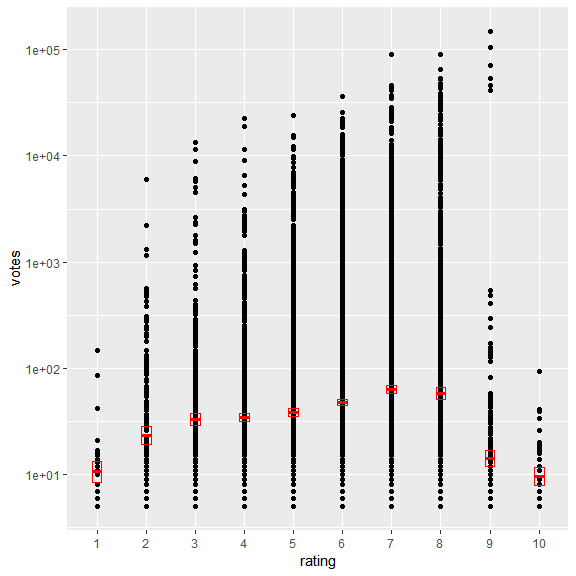

```r
# take a look at the variables in movies_small
# glimpse(movies_small) # %>% kableExtra::kable(format = "html", booktabs = T, caption = "Table Variables")
# kable_styling(latex_options = c("striped", "hold_position"), full_width = F)

# Build a scatter plot with mean and 95% CI
ggplot(movies_small, aes(x = rating, y = votes)) +
  geom_point() +
  stat_summary(fun.data = "mean_cl_normal",
               geom = "crossbar",
               width = 0.2,
               col = "red") +
  scale_y_log10()
```

## Refresher (2)

The plot in the graphics device is a variation on an oft-seen `ggplot2` example using the `diamonds` dataset (containing information on several variables of over 50,000 diamonds).

Recall that there are a variety of `scale_` functions. Here, data are transformed or filtered first, after which the plot and associated statistics are computed. For example, scale_y_continuous(limits = c(100, 1000) will remove values outside that range.

Contrast this to `coord_cartesian()`, which computes the statistics before plotting. That means that the plot and summary statistics are performed on the raw data. That’s why we say that `coord_cartesian(c(100, 1000))` “zooms in” a plot. This was discussed in the chapter on coordinates in course 2.

Here we’re going to expand on this and introduce `scale_x_log10()` and `scale_y_log10()` which perform *log10* transformations, and `coord_equal()`, which sets an aspect ratio of 1 (`coord_fixed()` is also an option).

Your task is to reproduce the plot in the viewer. Before you do this, it might be a good idea to explore diamonds in the console if you are not familiar with it.

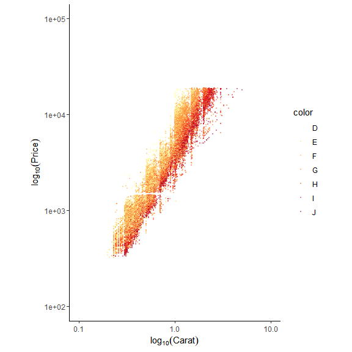

```r
# Reproduce the plot
ggplot(diamonds, aes(x = carat, y = price, col = color)) +
  geom_point(alpha = 0.5, size = 0.5, shape = 16) +
  scale_x_log10(expression(log[10](Carat)), limits = c(0.1,10)) +
  scale_y_log10(expression(log[10](Price)), limits = c(100,100000)) +
  scale_color_brewer(palette = "YlOrRd") +
  coord_equal() +
  theme_classic()
```

Good job! This is a nice way of transforming data and then plotting it in one command.

## Refresher (3)

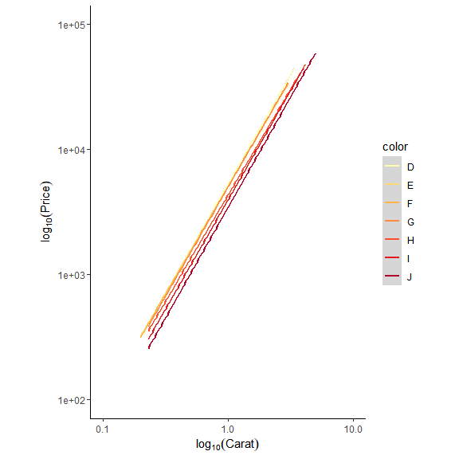

```r
# Add smooth layer and facet the plot
ggplot(diamonds, aes(x = carat, y = price, col = color)) +
  stat_smooth(method = "lm") +
  # geom_point(alpha = 0.5, size = 0.5, shape = 16) +
  scale_x_log10(expression(log[10](Carat)), limits = c(0.1,10)) +
  scale_y_log10(expression(log[10](Price)), limits = c(100,100000)) +
  scale_color_brewer(palette = "YlOrRd") +
  coord_equal() +
  theme_classic()
```

Good job! Parametric and non-parametric linear models are common in scatter plots.

## Box Plots

In this section we’ll take a look at our first class of specialized plots—or statistical plots—actually all the plots we’ve made so far can be called statistical plots since data visualization *operates at the intersection of design and statistics*. However, in contrast to the plots we’ve seen previously, these are more well-suited to an academic audience. We are going to look at two very common plot types for visualizing the distribution of continuous data:

- Box plots
- Density plots

We’ll return to boxplots in the case study when we develop a new statistics layer to produce a two-dimensional box plot.

|  | **robust** | **non-robust** |
| --- | --- | --- |
| center | median | mean |
| spread | IQR | SR, range |

Table 1: median & IQR only depend on the midpoint of the distribution and the values of the end point are irrelevant to its calculation, whereas mean & SD are affected. Hence, mean & SD are usually good for symmetric or normal distributions.

The Five Number Summary gives us a better impression of the distribution of the dataset. We get an impression of the skew because each of the four segments—the two outer whiskers and the two parts of the inner bar—reflect 25% of the data. There is a further subtle point to boxplots: The ability to show extreme values as distinct features. An extreme value is defined as **falling outside the range of 1.5 times the IQR, either below Q1 or above Q3**. This is called the **fence**[^2]. To understand how the fence works, we’ll use the same dataset we’ve working so far, but we’ll pull the maximum value further and further away from its starting position causing the dataset to slowly become positively skewed. Any value that surpasses the fence will be drawn as a dot, the boxplot is also updated; the whisker is drawn up to the highest elevation *within* the fence. It doesn’t matter how many values are outside the fence or how faraway they are, they all get represented as dots. The whiskers never extend beyond the fence. If you are not clear about how the plot is drawn, you can actually get the wrong view of the data distribution. Many people who commonly use or encounter boxplots are not aware that the midline is the median and not the mean. Nor are they aware that the dots represents extreme values that are part of the data, and therefore should not be disregarded. So use these plots with caution.

### Transformations

In this exercise you’ll return to the first plotting exercise and see how box plots compare to dot plots for representing high-density data.

Box plots are very useful, but they don’t solve all your problems all the time, for example, when your data are heavily skewed, you will still need to transform it. You’ll see that here, using the movies_small dataset, a subset of 10,000 observations of `ggplot2movies::movies`

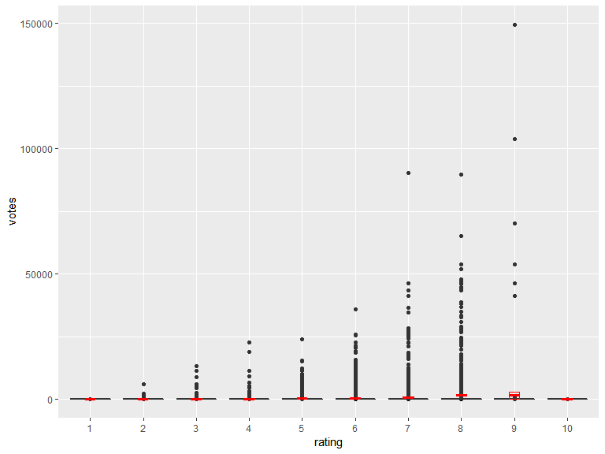

```r
# movies_small is available

# Add a boxplot geom
d <- ggplot(movies_small, aes(x = rating, y = votes)) +
  geom_point() +
  geom_boxplot() +
  stat_summary(fun.data = "mean_cl_normal",
               geom = "crossbar",
               width = 0.2,
               col = "red")

# Untransformed plot
d
```

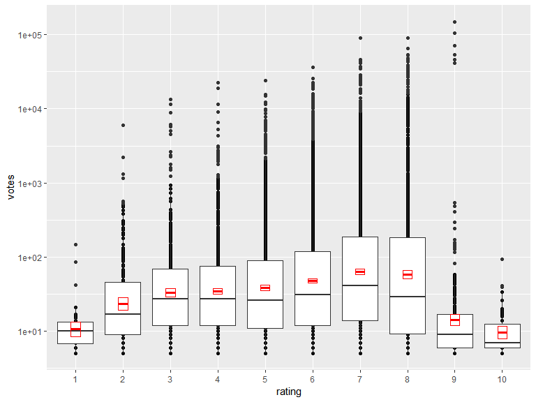

```r
# Transform the scale
d + scale_y_log10() # the transformation happens before calculating the statistics
```

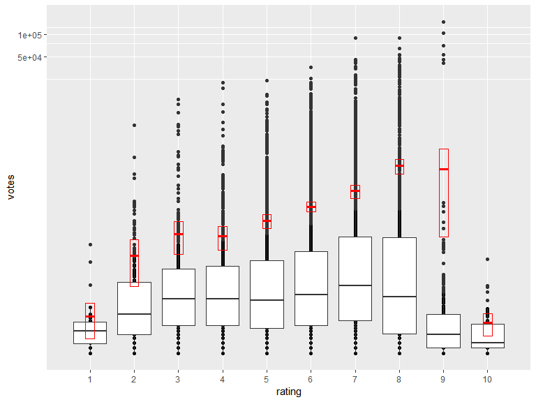

```r
# Transform the coordinates
d + coord_trans(y = "log10") # the transformation happens after calculating the statistics
```

Good job! Notice how different the normal distribution estimation (red boxes) and boxplots (less prone to outliers) are.

### Cut it up!

If you only have continuous variables, you can convert them into ordinal variables using any of the following functions:

- `cut_interval(x, n)` makes n groups from vector x with equal range.
- `cut_number(x, n)` makes n groups from vector x with (approximately) equal numbers of observations.
- `cut_width(x, width)` makes groups of width width from vector x.

This is useful when you want to summarize a complex scatter plot like the one shown in the viewer. By applying these functions to the carat variable and mapping that onto the group aesthetic, you can convert the scatter plot in the viewer into a series of box plots on the fly.

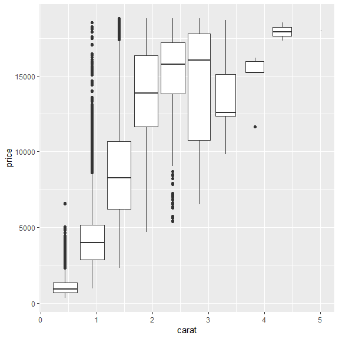

```r
# Plot object p
p <- ggplot(diamonds, aes(x = carat, y = price))

# Use cut_interval
p + geom_boxplot(aes(group = cut_interval(carat, n = 10)))
```

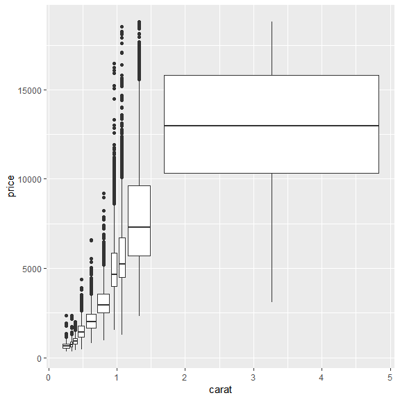

```r
# Use cut_number
p + geom_boxplot(aes(group = cut_number(carat, n = 10)))
```

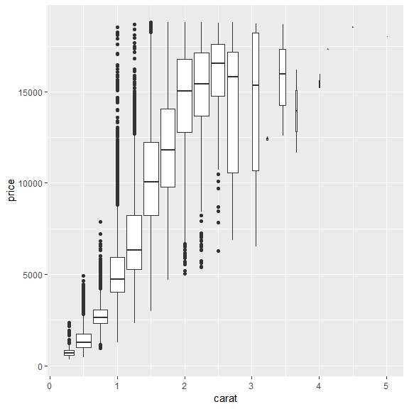

```r
# Use cut_width
p + geom_boxplot(aes(group = cut_width(carat, width = 0.25)))
```

Good job! Going from a continuous to a categorical variable reduces the amount of information, but sometimes that helps us understand the data.

### Understanding quartiles

Be aware that there are many ways to calculate the IQR, short for inter-quartile range (that is $Q3−Q1$). These are defined in the help pages for the `quantile()` function:

> ?quantile

To explore the differences in these types, a function called `plot_quart()` is available, that takes one argument: an integer specifying the number of values. Using `rnorm()` a vector of values will be generated and the quartiles will be calculated using nine different methods. Run the command in the console on the right using different values (for example 4, 10, 50, 100).

What can you say about how the quartiles and the IQR are calculated?

```r
plot_quart <- function(n) {
  set.seed(123)
  playData <- data.frame(raw.values = rnorm(n, 1, 6))

  quan.summary <- data.frame(t(sapply(1:9, function(x) quantile(playData$raw.values, type = x))))
  names(quan.summary) <- c("Min", "Q1", "Median", "Q3", "Max")
  quan.summary$Type <- as.factor(1:9)

  library(reshape2)
  quan.summary <- melt(quan.summary, id = "Type")
  quan.summary <- list(quartiles = quan.summary, values = playData)

  ggplot(quan.summary$quartiles, aes(x = Type, y = value, col = variable)) +
    geom_point() +
    geom_rug(data = quan.summary$values, aes(y = raw.values), sides = "l", inherit.aes = F)
}
```

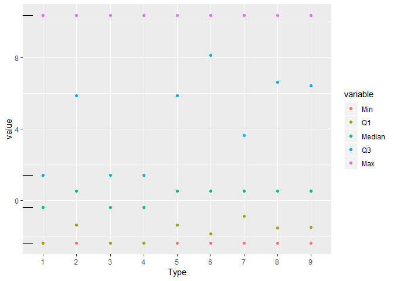

```r
par(mfrow = c(2, 2))

plot_quart(4)
```

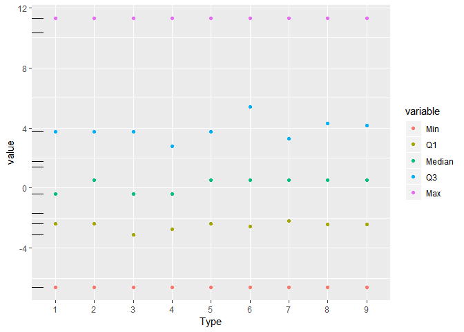

```r
plot_quart(10)
```

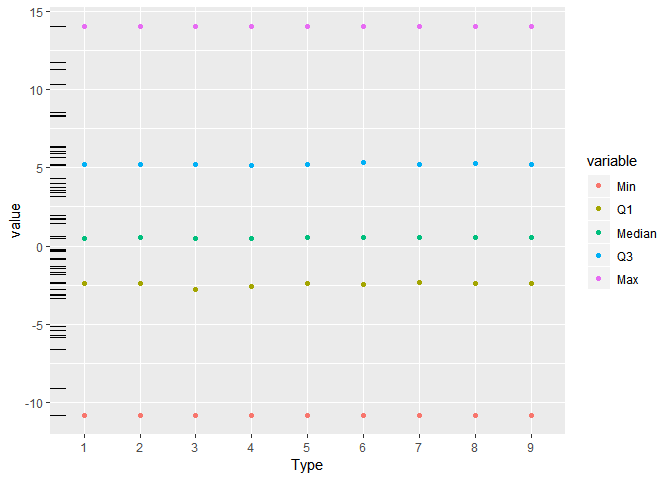

```r
plot_quart(50)
```

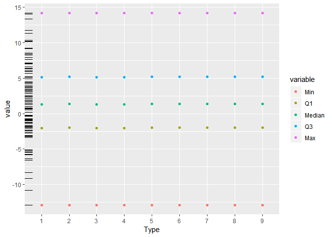

```r
plot_quart(100)
```

**The IQR becomes more consistent across methods as the sample size increases**. Yes, the subtle difference between methods is not as pronounced when the sample size is large. In any case, you are likely to encounter spurious artefacts when drawing box plots with small sample sizes.

## Density Plots

Density plots are an excellent way of visualizing the data distributions of a univariate data set. They are less common than histograms and somewhat poorly understood, but actually they are quite intuitive. If you’ve already looked at a statistics book, you’ve already seen a lot of density plots e.g. probability density functions (PDFs)—(like the normal, students t-distribution, chi-sq, and F-distributions amongst many)—are simply theoretical PDFs. Here, we are going to make an empirical PDF. So instead of making a density plot based on a formula, it is going to be based on our data. But the purpose is basically the same. To do this we need to use the *Kernel Density Estimator* (KDE).

> The Kernel Density Estimate is a sum of ‘bumps’ placed at the observations. The kernel function determines the shape of the bumps while the window width, h, determines their width [see @hothorn_handbook_2014].

### geom_density()

To make a straightforward density plot, add a `geom_density()` layer.

Before plotting, you will calculate the emperical density function, similar to how you can use the `density()` function in the `stats` package, available by default when you start R. The following default parameters are used (you can specify these arguments both in density() as well as geom_density()):

- `bw = "nrd0"`, telling R which rule to use to choose an appropriate bandwidth.
- `kernel = "gaussian"`, telling R to use the Gaussian kernel.

We’ve already prepared a data frame test_data for you, containing three columns: norm, bimodal and uniform. Each column represents 200 samples from a normal, bimodal and uniform distribution.

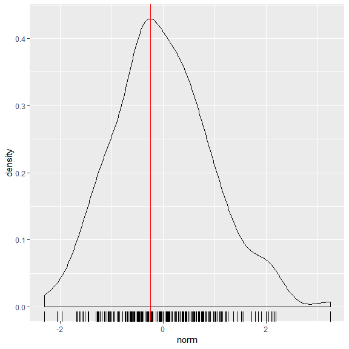

```r
load("datasets/test_datasets.RData")

test_data <- ch1_test_data

# Calculating density: d
d <- density(test_data$norm)

# Use which.max() to calculate mode
mode <- d$x[which.max(d$y)]

# Finish the ggplot call
ggplot(test_data, aes(x = norm)) +
  geom_rug() +
  geom_density() +
  geom_vline(xintercept = mode, col = "red")
```

Good job! Recall that density plots can be combined in many ways, as we’ll see in the next exercise.

### Combine Density Plots and Histogram

Sometimes it is useful to compare a histogram with a density plot. However, the histogram’s y-scale must first be converted to frequency instead of absolute count. After doing so, you can add an empirical PDF using `geom_density()` or a theoretical PDF using `stat_function()`.

Can you finish the plot below by following the steps?

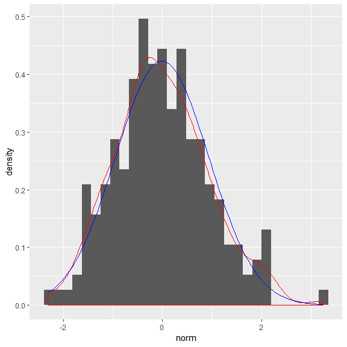

```r
# Arguments you'll need later on
fun_args <- list(mean = mean(test_data$norm), sd = sd(test_data$norm))

# Finish the ggplot
ggplot(test_data, aes(x = norm)) + # set the y aesthetic to the internal ..density.. variable, overriding the default ..count...
  geom_histogram(aes(y = ..density..)) +
  geom_density(col = "red") +
  stat_function(fun = dnorm, args = fun_args, col = "blue")
```

Good job! Don’t go too crazy on overlapping plots, or things get too confusing.

### Adjusting Density Plots

There are three parameters that you may be tempted to adjust in a density plot:

- `bw` - the smoothing bandwidth to be used, see ?density for details
- `adjust` - adjustment of the bandwidth, see density for details
- `kernel` - kernel used for density estimation, defined as
- “g” = gaussian
- “r” = rectangular
- “t” = triangular
- “e” = epanechnikov
- “b” = biweight
- “c” = cosine
- “o” = optcosine

In this exercise you’ll use a dataset containing only four points, `small_data`, so that you can see how these three arguments affect the shape of the density plot.

The vector `get_bw` contains the bandwidth that is used by default in `geom_density()`. `p` is a basic plotting object that you can start from.

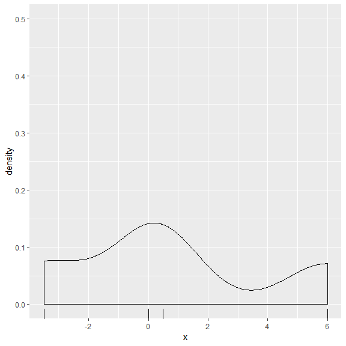

```r
small_data <- data.frame(x = c(-3.5, 0.0, 0.5, 6.0))

# Get the bandwith
get_bw <- density(small_data$x)$bw

# Basic plotting object
p <- ggplot(small_data, aes(x = x)) +
  geom_rug() +
  coord_cartesian(ylim = c(0,0.5))

# Create three plots
p + geom_density()
```

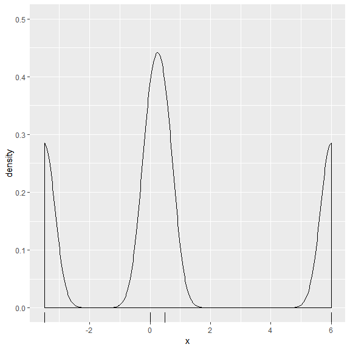

```r
p + geom_density(adjust = 0.25)
```

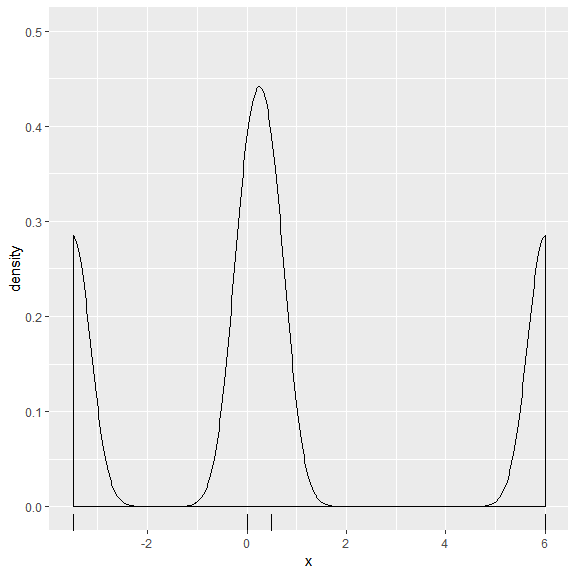

```r
p + geom_density(bw = 0.25 * get_bw)
```

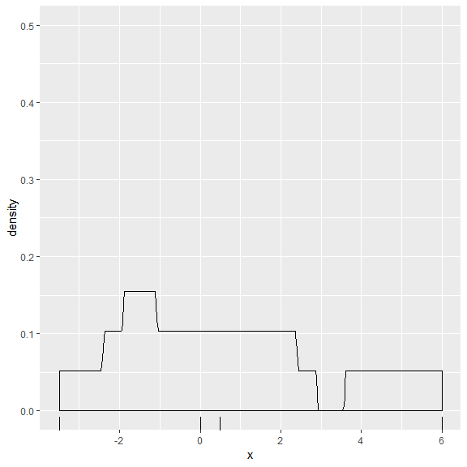

```r
# Create two plots
p + geom_density(kernel = "r")
```

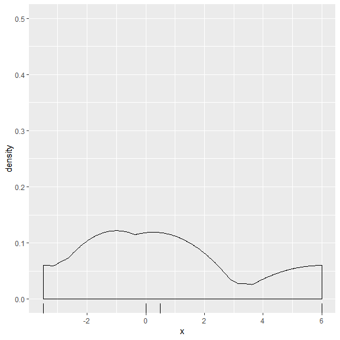

```r
p + geom_density(kernel = "e")
```

Good job! Notice how the curve contained more features and their individual heights were increased as the bandwidth decreased.

## Multiple Groups / Variables

By **Groups** we mean levels within a factor variable. In this case it is the eating habits of different mammals. This distribution we are interested in is the amount of total sleep time experienced by each mammal. Up until this point we would have used a `geom_point()` with `position_jitter(0.2)`, but we’ve seen that we can also use *boxplots*. (I should point out that although we could use boxplots in this case it is not really reasonable since the insectivore group only has five observations. The problem with boxplots is that they don’t show information about the number of observations. We can remedy this situation by setting the width of each box relative to the *n* value of each group.).

```r
(mammals <- read_rds(here("datasets/mammals.RDS")))
```

```
#> # A tibble: 76 x 2
#>    vore      sleep_total
#>    <fct>           <dbl>
#>  1 Carnivore        12.1
#>  2 Omnivore         17
#>  3 Herbivore        14.4
#>  4 Omnivore         14.9
#>  5 Herbivore         4
#>  6 Herbivore        14.4
#>  7 Carnivore         8.7
#>  8 Carnivore        10.1
#>  9 Herbivore         3
#> 10 Herbivore         5.3
#> # ... with 66 more rows
```

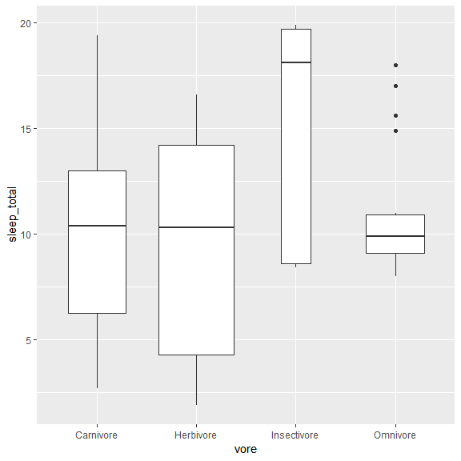

```r
# Not recommended for this dataset
ggplot(mammals, aes(x = vore, y = sleep_total)) +
  geom_boxplot(varwidth = TRUE)
```

Density plots could work in this situation. The advantage here is that we can overlay multiple data density plots on top of each other. So we can compare distributions more easily, which is pretty nice. However, we once again lose information about the group size since it appears that insectivores–the blue curve–is very abundant. To correct for this we can weight each density plot according to the proportion of observations of each group. The resulting plot shows that **Herbivores** are the most abundant group and there are very few observations in insectivores. If we want to see multiple density plots side by side we could facet our plots, but there is a alternative–the violin plot.

The violin plot is a relatively new plot type, which is gaining in popularity. The violin plot basically puts a density plot onto a vertical axis and then mirrors it to create a symmetrical 2-D shape. This can really aid in comparing different distributions. Just like with the regular density plot we should also consider weighting each group according to its *n* value. With this plot we can compare many groups within a variable.

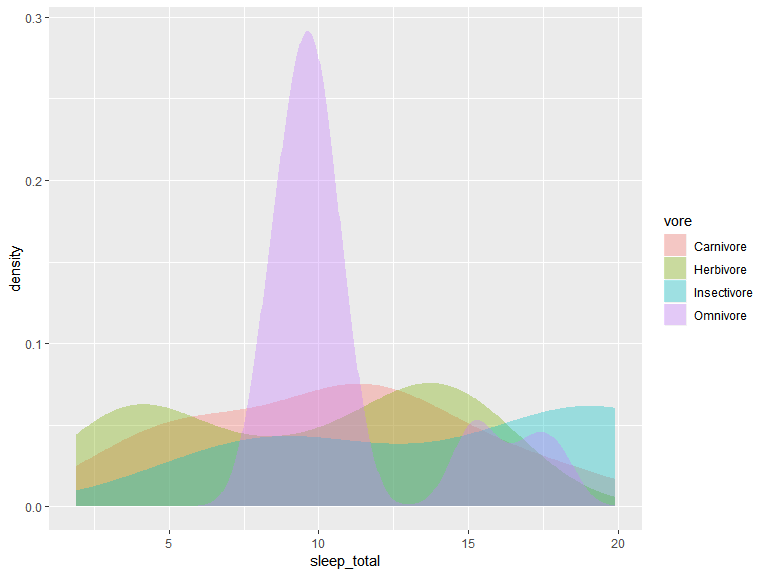

```r
ggplot(mammals, aes(x = sleep_total, fill = vore)) +
  geom_density(col = NA, alpha = 0.35)
```

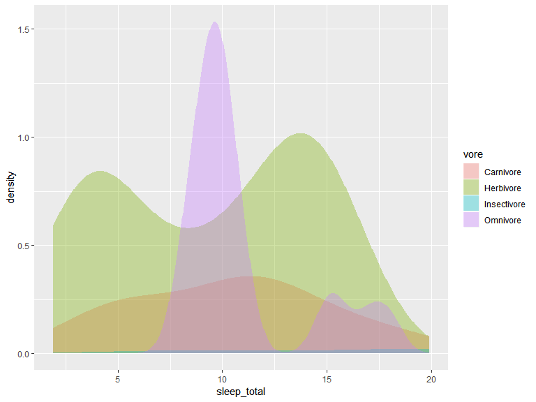

```r
# Add weights
mammals <- mammals %>%
  group_by(vore) %>%
  mutate(n = n()/nrow(mammals))

ggplot(mammals, aes(x = sleep_total, fill = vore)) +
  geom_density(aes(weight = n), col = NA, alpha = 0.35)



```

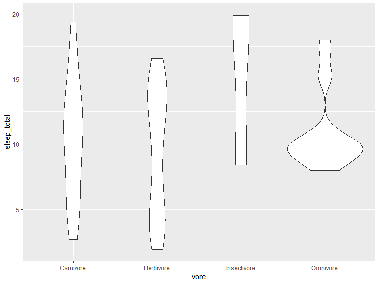

```r
ggplot(mammals, aes(x = vore, y = sleep_total)) +
  geom_violin()
```

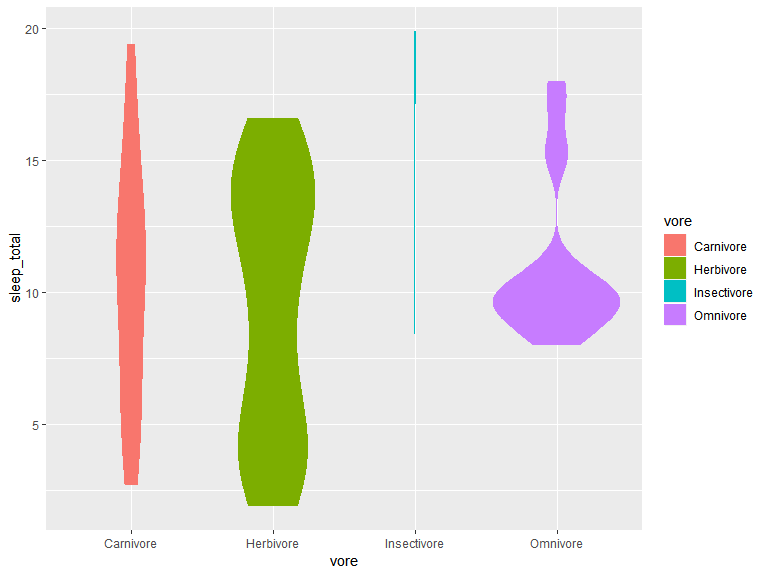

```r
ggplot(mammals, aes(x = vore,
                    y = sleep_total,
                    fill = vore)) +
  geom_violin(aes(weight = n), col = NA)



```

### Comparing separate variables

The other plot I mentioned was comparing separate variables. For that, let’s a take at a classic example: the eruption and waiting duration of the old faithful geyser at the Yellowstone National Park. At the outset it appears that the main relationship between this two variables is linear (see the scatter plot below), which will be correct. But more subtle that that the data is also bimodal from both axes i.e. you either wait a long time and get a longer eruption or you wait a short time and get a shorter eruption. There are relatively few data points in between. For this, we can use a 2-D density plot (see density plot below), which appears something like a contour plot. If you’ve ever seen a topograhical map, the concept is the same: the more concentric a ring is, the higher the density. A nice effect here is to fill in the regions according to their density. We encountered monochromatic color scales in the first two courses, which I advocated for in the case of continuous data. However, the viridis color scale (shown below) has recently gained in popularity (we will explore its advantages in the exercises.).

A 2-D density plot emphasizes the bimodal nature of this dataset so sometimes it can be quite useful to consider distributions in 2-D. We will see density plots make a reappearance when we talk about Kenury plots in the next chapter where we have three variables. Another advantage of the ggplot2 structure is that we can use the underlying statistics with a different `geom` so instead of producing a contour or filled density plot, we can calculate the density by calculating the values using a grid of circles whose sizes varies according to the underlying density.

```r
data("faithful")

dim(faithful)
```

```
#> [1] 272   2
```

```r
head(faithful)
```

```
#>   eruptions waiting
#> 1     3.600      79
#> 2     1.800      54
#> 3     3.333      74
#> 4     2.283      62
#> 5     4.533      85
#> 6     2.883      55
```

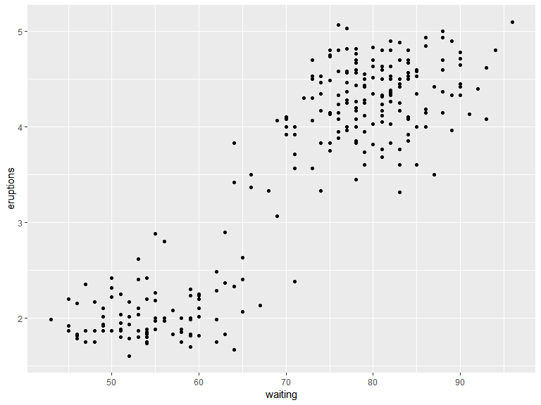

```r
# Scatter Plot
ggplot(faithful, aes(x = waiting, y = eruptions)) +
  geom_point()
```

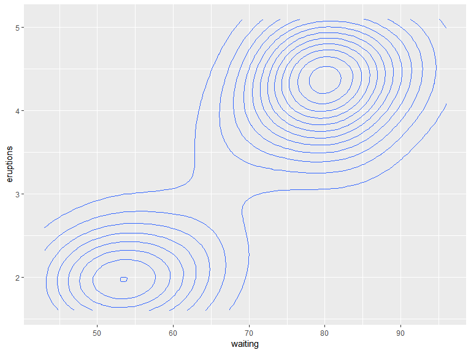

```r
# 2-D Density Plot
ggplot(faithful, aes(x = waiting, y = eruptions)) +
  geom_density_2d()
```

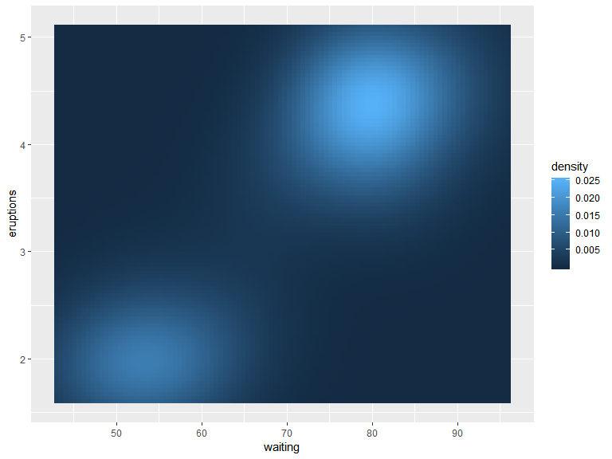

```r
# 2-D Density Plot w/ Monochromatic Color Scales
ggplot(faithful, aes(x = waiting, y = eruptions)) +
  stat_density_2d(geom = "tile",
                  aes(fill = ..density..),
                  contour = FALSE)
```

```r
library(viridis)
```

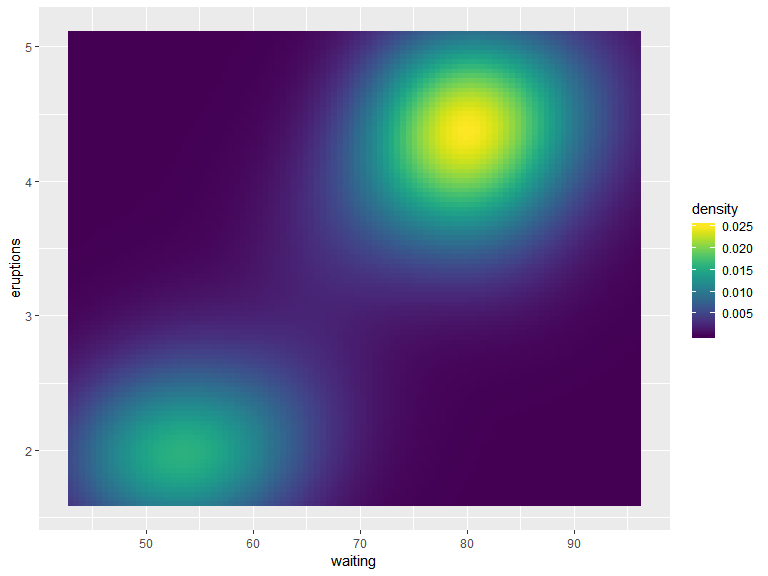

```r
ggplot(faithful, aes(x = waiting, y = eruptions)) +
  stat_density_2d(geom = "tile", aes(fill = ..density..),
                  contour = FALSE) +
  scale_fill_viridis()
```

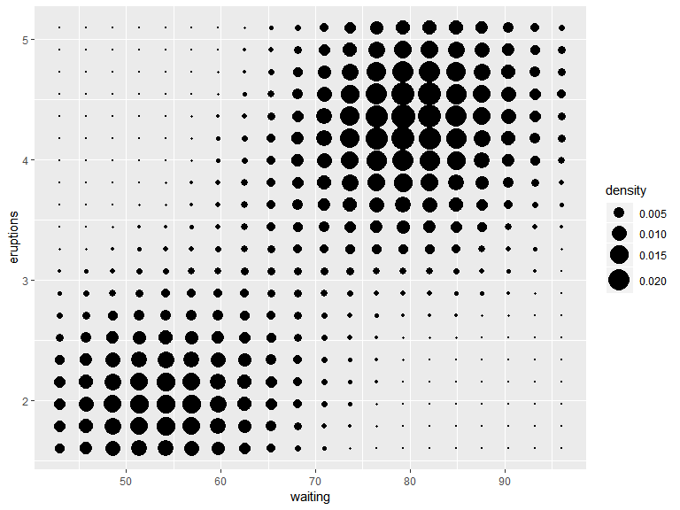

```r
ggplot(faithful, aes(x = waiting, y = eruptions)) +
  stat_density_2d(geom = "point",
                  aes(size = ..density..),
                  n = 20, contour = FALSE) +
  scale_size(range = c(0, 9))
```

## Exercises

### Boxplots with varying width

A drawback of showing a box plot per group, is that you don’t have any indication of the sample size, *n*, in each group, that went into making the plot. One way of dealing with this is to use a variable width for the box, which reflects differences in n.

Can you add some good-looking box plots to the basic plot coded on the right?

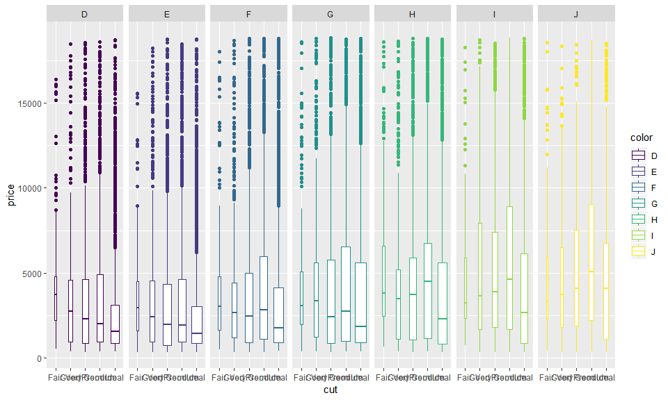

```r
ggplot(diamonds, aes(x = cut, y = price, col = color)) +
  geom_boxplot(varwidth = TRUE) +
  facet_grid(. ~ color) # +
```

```r
  # coord_flip()
```

### Multiple density plots

In this exercise you’ll combine multiple density plots. Here, you’ll combine just two distributions, a normal and a bimodal.

The first thing to remember is that you can consider values as two separate variables, like in the `test_data` data frame, or as a single continuous variable with their ID as a separate categorical variable, like in the `test_data2` data frame. `test_data2` is more convenient for combining and comparing multiple distributions.

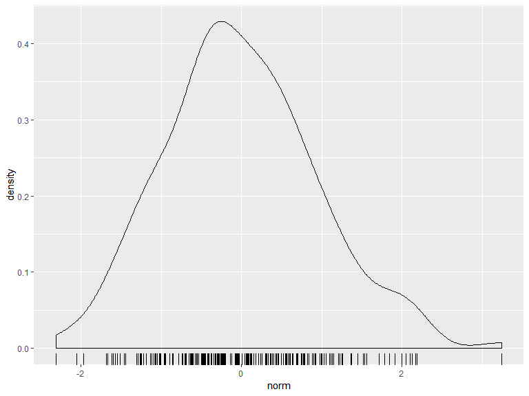

```r
test_data2 <- ch1_test_data2

# Plot with test_data
ggplot(test_data, aes(x = norm)) +
  geom_rug()+
  geom_density()
```

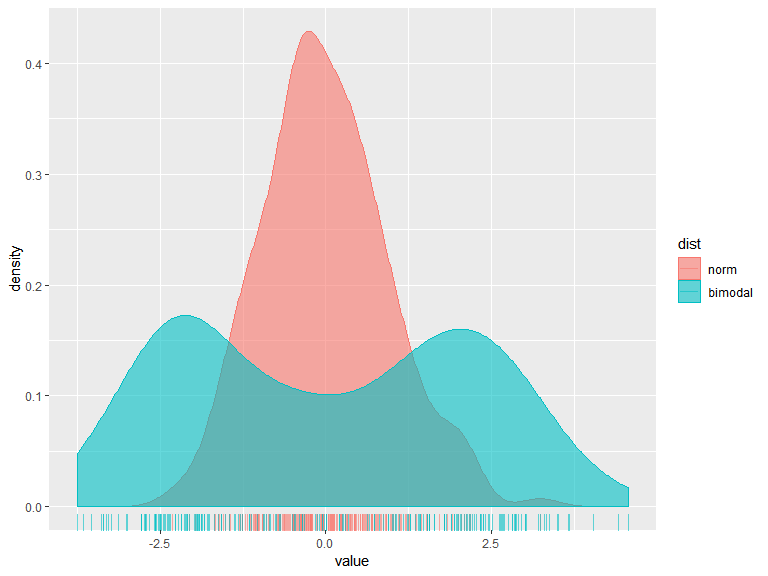

```r
# Plot two distributions with test_data2
ggplot(test_data2, aes(x = value, fill = dist, col = dist)) +
  geom_rug(alpha = 0.6) +
  geom_density(alpha = 0.6)
```

Good job! A small number of overlapping density plots are a fantastic way of comparing distinct distributions, for example, when descriptive statistics only (mean and sd) don’t represent the data well enough.

### Multiple density plots (2)

When you looked at multiple box plots, you compared the total sleep time of various mammals, sorted according to their eating habits. One thing you noted is that for insectivores, box plots didn’t really make sense, since there were only 5 observations to begin with. You decided that you could nonetheless use the width of a box plot to show the difference in sample size between the groups. Here, you’ll see a similar thing with density plots.

A cleaned up version of the mammalian dataset is available as `mammals`.

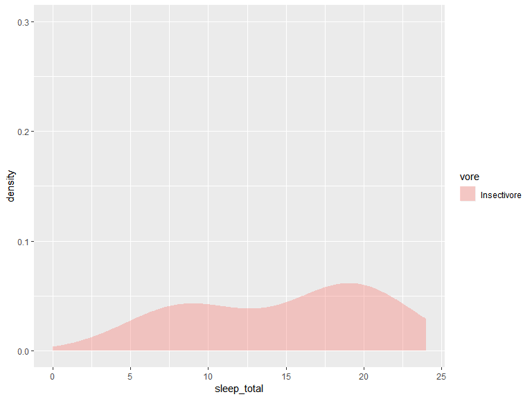

```r
# Individual densities
# In the first plot, filter the mammals dataset to plot only the vore variable that equals "Insectivore".
ggplot(mammals[mammals$vore == "Insectivore", ], aes(x = sleep_total, fill = vore)) +
  geom_density(col = NA, alpha = 0.35) +
  scale_x_continuous(limits = c(0, 24)) +
  coord_cartesian(ylim = c(0, 0.3))
```

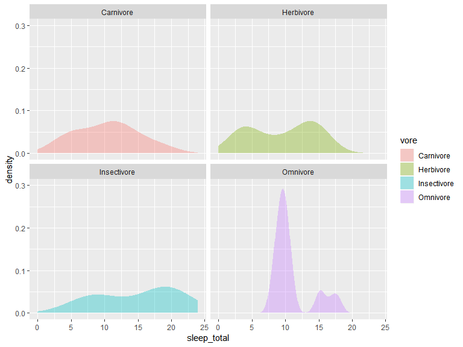

```r
# With faceting
# Instead of filtering, add facet_wrap() to the second plot;
# using ~ vore and nrow = 2 to arrange the plots. Compare this to the first plot.
ggplot(mammals, aes(x = sleep_total, fill = vore)) +
  geom_density(col = NA, alpha = 0.35) +
  scale_x_continuous(limits = c(0, 24)) +
  coord_cartesian(ylim = c(0, 0.3)) +
  facet_wrap( ~ vore, nrow = 2)
```

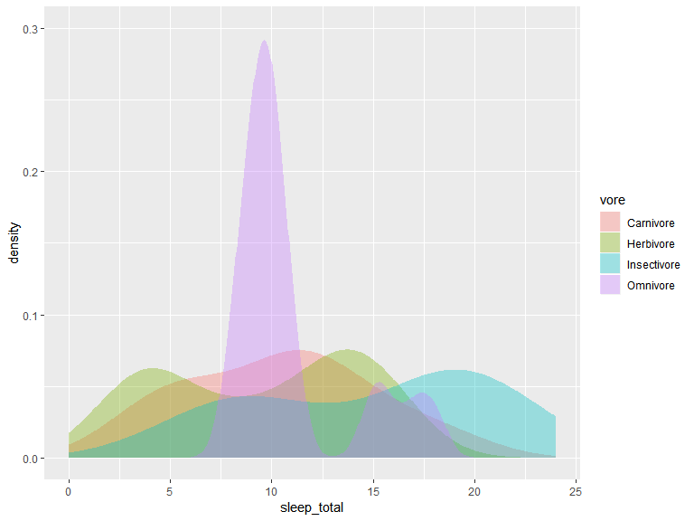

```r
# Note that by default, the x ranges fill the scale
# In the third plot, combines all the density plots together by mapping vore onto the fill aesthetic.
# The density plots are calculated separately for each group, which is derived from the fill aesthetic here.
ggplot(mammals, aes(x = sleep_total, fill = vore)) +
  geom_density(col = NA, alpha = 0.35) +
  scale_x_continuous(limits = c(0, 24)) +
  coord_cartesian(ylim = c(0, 0.3))
```

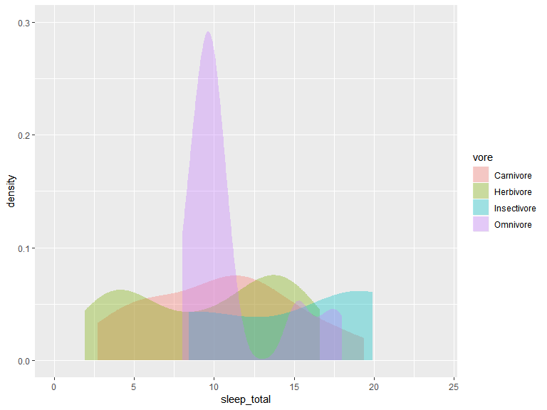

```r
# Trim each density plot individually
# Multiple density plots extend the range of all values to the total extent of the entire dataset.
# This may be a bit confusing, so in the fourth plot, in addition to mapping vore to fill,
# modify this by setting trim = TRUE inside geom_density(). However, be cautious.
# Since the distributions are cut off at the extreme ends, the area under the curve technically is not equal to one anymore.
ggplot(mammals, aes(x = sleep_total, fill = vore)) +
  geom_density(col = NA, alpha = 0.35, trim = TRUE) +
  scale_x_continuous(limits=c(0,24)) +
  coord_cartesian(ylim = c(0, 0.3))
```

A job well done! These simple tweeks make for great-looking statistical plots!

### Weighted density plots

When plotting a single variable, the density plots (and their bandwidths) are calculated separate for each variable (see the plot from the previous exercise, provided).

However, when you compare several variables (such as eating habits) it’s useful to see the density of each subset in *relation* to the whole data set. This holds true for multiple density plots as well as for violin plots.

For this, we need to weight the density plots so that they’re relative to each other. Each density plot is adjusted according to what proportion of the total data set each sub-group represents. We calculated this using the `dplyr` commands on lines 11-15.

The `mammals` data frame is available as before. After executing the commands, it will have the variable n, which we’ll use for weighting.

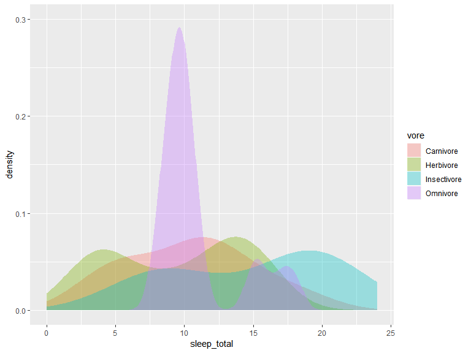

```r
# Unweighted density plot from before
ggplot(mammals, aes(x = sleep_total, fill = vore)) +
  geom_density(col = NA, alpha = 0.35) +
  scale_x_continuous(limits = c(0, 24)) +
  coord_cartesian(ylim = c(0, 0.3))
```

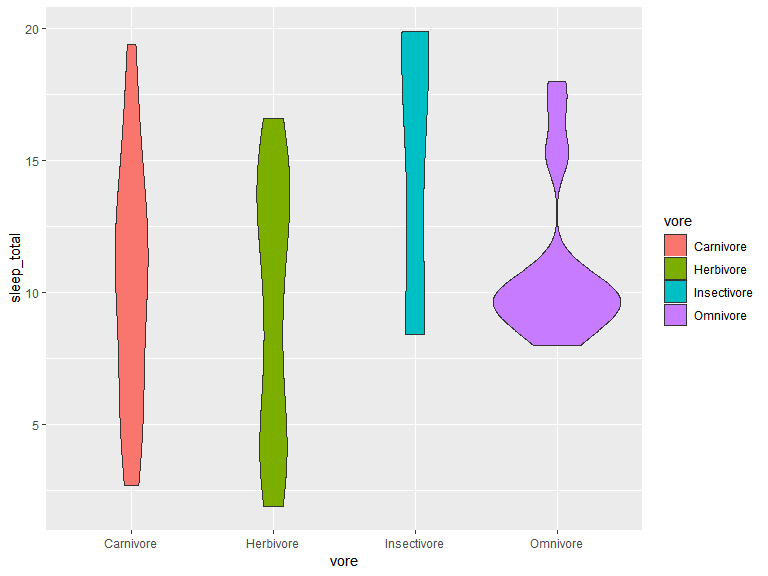

```r
# Unweighted violin plot
ggplot(mammals, aes(x = vore, y = sleep_total, fill = vore)) +
  geom_violin()
```

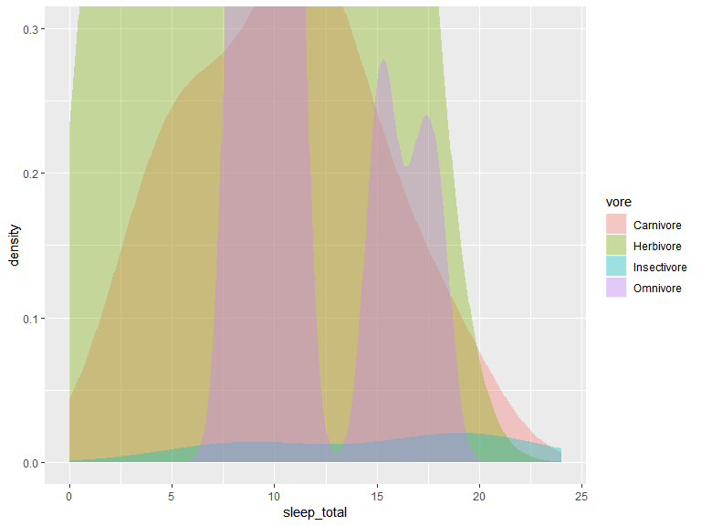

```r
# Calculate weighting measure
# library(dplyr)
mammals2 <- mammals %>%
  group_by(vore) %>%
  mutate(n = n() / nrow(mammals)) -> mammals

# Weighted density plot
ggplot(mammals2, aes(x = sleep_total, fill = vore)) +
  geom_density(aes(weight = n), col = NA, alpha = 0.35) +
  scale_x_continuous(limits = c(0, 24)) +
  coord_cartesian(ylim = c(0, 0.3))



```

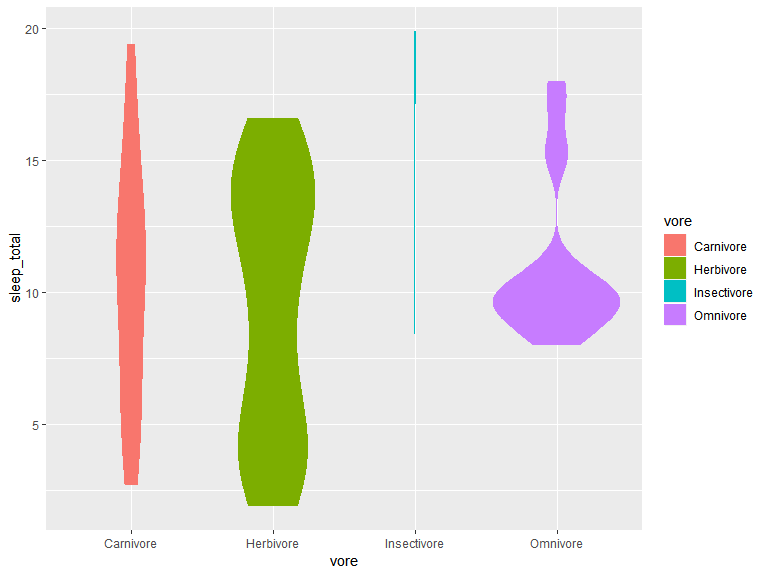

```r
# Weighted violin plot
ggplot(mammals2, aes(x = vore, y = sleep_total, fill = vore)) +
  geom_violin(aes(weight = n), col = NA)



```

Wonderful weighting! These density plots are more detailed and accurate.

### 2D Density Plots (1)

You can consider two orthogonal density plots in the form of a 2D density plot. Just like with a 1D density plot, you can adjust the bandwidth of both axes independently.

The data is stored in the `faithful` data frame, available in the datasets package. The object `p` contains the base definitions of a plot.

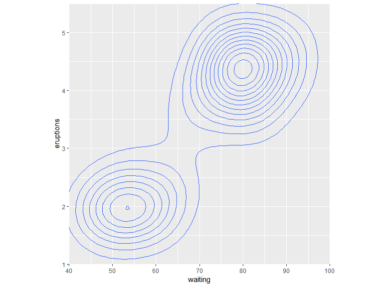

```r
# Base layers
p <- ggplot(faithful, aes(x = waiting, y = eruptions)) +
  scale_y_continuous(limits = c(1, 5.5), expand = c(0, 0)) +
  scale_x_continuous(limits = c(40, 100), expand = c(0, 0)) +
  coord_fixed(60 / 4.5)

# 1 - Use geom_density_2d()
p + geom_density_2d()
```

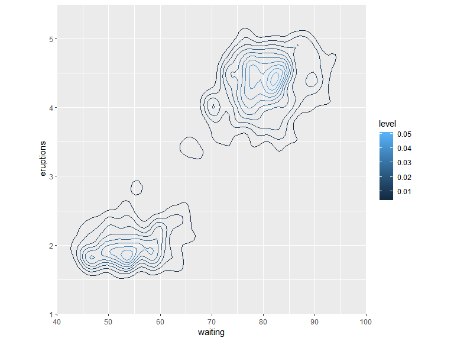

```r
# 2 - Use stat_density_2d() with arguments
p + stat_density_2d(aes(col = ..level..), h = c(5, 0.5))
```

2D Triumph! Think about the message in your scatter plots, sometimes clusters of high-density are more intersting than linear models.

### 2D Density Plot (2)

Continuing with the density plots from the last exercise, here you’ll explore the viridis package. This package contains multi-hue color palettes suitable for continuous variables.

The advantage of these scales is that instead of providing an even color gradient for a continuous scale, they highlight the highest values by using an uneven color gradient on purpose. The high values are lighter colors (yellow versus blue), so they stand out more.

A shaded 2D density plot showing the same data as the previous exercise has been provided for you. Up to you to upgrade it!

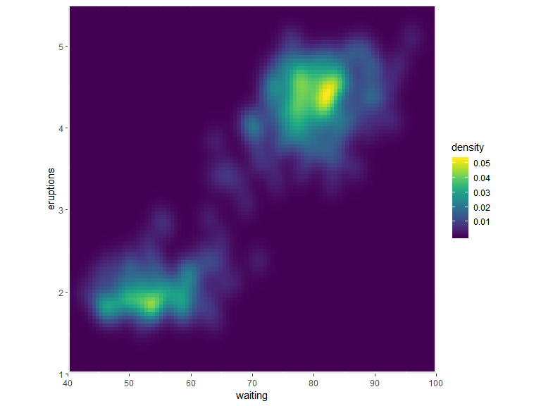

```r
# Load in the viridis package
# library(viridis)

# Add viridis color scale
ggplot(faithful, aes(x = waiting, y = eruptions)) +
  scale_y_continuous(limits = c(1, 5.5), expand = c(0,0)) +
  scale_x_continuous(limits = c(40, 100), expand = c(0,0)) +
  coord_fixed(60/4.5) +
  stat_density_2d(geom = "tile", aes(fill = ..density..), h=c(5,.5), contour = FALSE) +
  scale_fill_viridis()
```

Dynamite density! Off to the next chapter!

## References

[^1]: robust statistics are measures on which extreme observations have little effect.
[^2]: Note: The fence can be adjusted and the default depends on the software.